# Differential Gene Expression (DGE): analysis procedures & vizualization

TS O’Leary

# The what, the why, & the how

## What is differential expression?

- Looking for a difference in gene transcript abundance between experimental groups.
- So that means you can find specific genes that have changed there expression.
- Which genes are changing? How many? What do those genes do?
- But this leads to the obvious question, what defines a change?
  - Changes greater than what would be expected by random variation.
  - Want only significant changes. That means statistics!
  - We will get into that a bit later.

## Why use differential expression?

- Melissa did a great job providing motivation for doing transcriptomics, so I won’t go into much detail here to save time.
- But if we are fundamentally interested in how Genotype leads to Phenotype then investigating transcription is one step closer to the phenotype.
- Could potentially give insight into how different populations have diverged or how they react to different environmental conditions or acclimations.

## How did we we get here?

I want to spend just a minute or so on how we got here and what you need to do as prep work to get to the point where you can start asking questions about differential expression.

I won’t go into the details here but I will refer you back to your notes from the first day with Erika and last week with Melissa

- Sample-prep
- RNA extraction
- Library Prep
- Sequencing
- Quality Control of raw reads
  - Visualization with FastQC (Andrews et al.)
  - Trimming with Trimmomatic (Bolger et al.)
- Mapping and counting
  - Salmon (Patro et al.)

# Normalization

So what we have at the end here is something that looks a bit like a data matrix or gene count table, where each row is a specfic gene and each column is a sample

## Why normalize?

There are two main problems that normalization is trying to address

- Differences in library sizes
- Differences in library composition

## Types of Normalization

Okay so, then how do they address those problems in the normalization process?

There are many procedures out there:

I will just spend some time going into some detail on DESeq2’s normalization method because:

- DESeq2 is one of the more popular packages out there
- it also happens to be what we will use with our data on Wednesday

## DESeq2 normalization

[Helpful video](https://www.youtube.com/watch?v=UFB993xufUU)

# Differential Expression!

## Multiple testing problem.

Helpful related videos

- [False Discovery Rates](https://www.youtube.com/watch?v=K8LQSvtjcEo)
- [Independent Filtering](https://www.youtube.com/watch?v=Gi0JdrxRq5s)
- [Statistical Models](https://www.youtube.com/watch?v=yQhTtdq_y9M)

# Visualization

## Sequencing summary statistics

SARTools is a useful tool (Varet et al.).

[This is what the output looks like!](https://tsoleary.github.io/rna_seq/cahan/results/whole_body_heat_cold_shock_report.html#4_normalization)

## Summary plots

### PCA

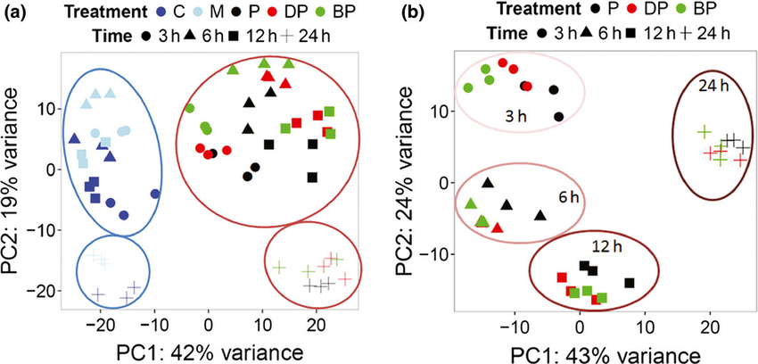

### Hieracrhical clustering and heat maps

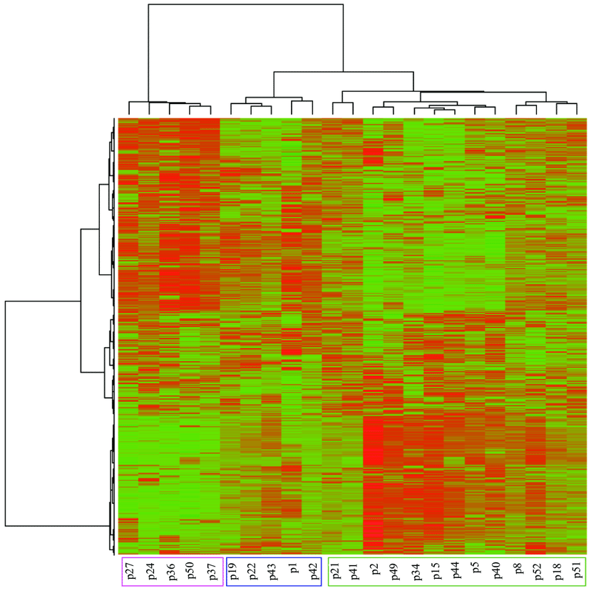

### VennDiagrams

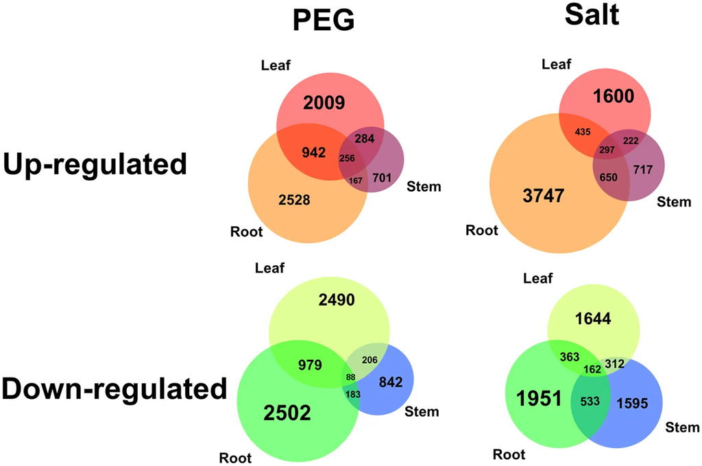

## DEG plots

### MA plots

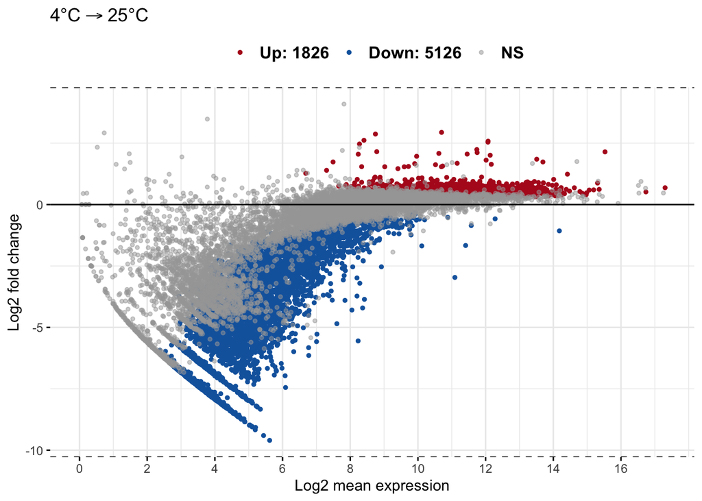

### Volcano plots

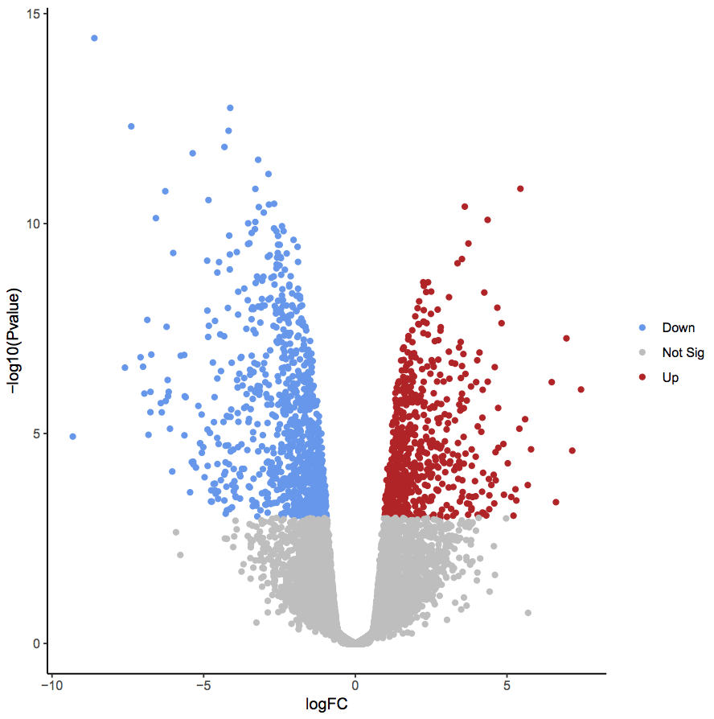

### LFC scatter plots

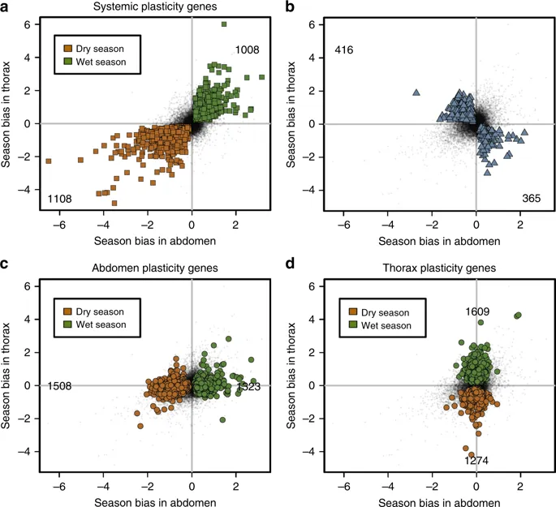

### Individual gene treatment response curves

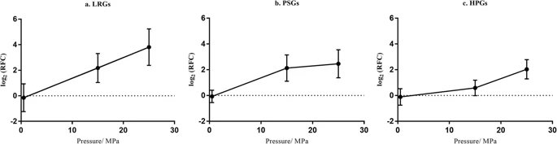

# Enrichment analysis

Okay so we found a bunch of genes changing, but how do we make sense out of all of the information. You can either search through it by hand, looking for your favorite genes or the genes with greatest relative fold change, or lowest p-value or something. But people have developed ways of trying to look for entire sets of genes or functional pathways that are changing. There are multiple functional databases that you can query and multiple ways that you can test for enrichment of particular gene sets.

## Functional databases (Gene sets)

GO and KEGG are among the more popular functional databases for analyzing gene sets. Pfam one of the databases that were used in the paper we read for today.

### Gene Ontology (GO)

[Gene Ontology overview](http://geneontology.org/docs/ontology-documentation/)

- **Molecular function** - molecular activities performed by gene products
  - catalytic activity
    - adenylate cyclase activity
  - transporter activity
    - Toll-like receptor binding.
- **Biological process** - the larger biological processes that the gene product is involved in
  - DNA repair
    - pyrimidine nucleobase biosynthetic process
  - signal transduction
    - glucose transmembrane transport
- **Cellular component** - cellular compartments or macromolecular complexes where the gene product performs its function
  - mitochondria
  - ribosome

There is a hierarchy of terms.

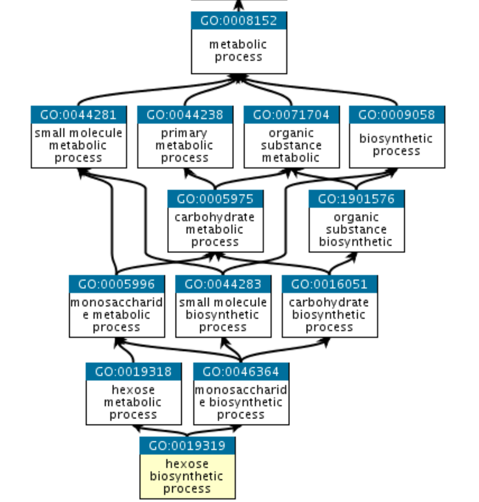

### KEGG pathway

[Kyoto Encyclopedia of Genes and Genomes](https://www.genome.jp/kegg/pathway.html) is similarly structured with sub sets. Genetic information processing -> Transcription -> Spliceosome

[figure not shown]

### Pfam: Protien families

Semi-automated method of curating protein family information to help annotate genomes.

[Example of a *Pfam* entry](https://pfam.xfam.org/family/PF02171)

## Methods of analysis

[clusterProfiler bookdown](https://yulab-smu.github.io/clusterProfiler-book/index.html)

### Over-representation analysis (ORA)

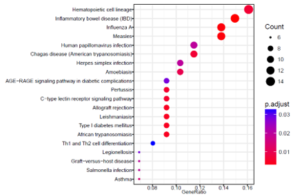

### Gene set enrichment analysis (GSEA)

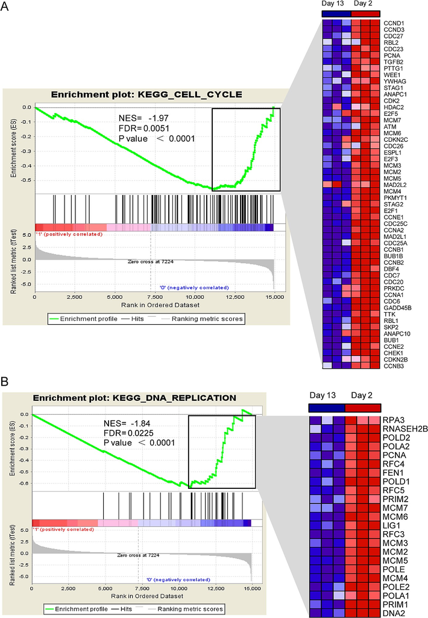

# References

Andrews, Simon, et al. *FastQC*. Babraham Institute, Jan. 2012, https://www.bioinformatics.babraham.ac.uk/projects/fastqc/.

Bolger, Anthony M., et al. “Trimmomatic: A flexible trimmer for Illumina sequence data.” *Bioinformatics*, vol. 30, no. 15, 2014, pp. 2114–20, doi:10.1093/bioinformatics/btu170.

Patro, Rob, et al. *Salmon: fast and bias-aware quantification of transcript expression using dual-phase inference*. no. 4, 2017, pp. 417–19, doi:10.1038/nmeth.4197.Salmon.

Varet, Hugo, et al. “SARTools: A DESeq2- and edgeR-based R pipeline for comprehensive differential analysis of RNA-Seq data.” *PLoS ONE*, vol. 11, no. 6, 2016, pp. 1–8, doi:10.1371/journal.pone.0157022.